# Project 2D Code_AO

Project 2 Code AO

## Scientific Question: Does the maintenance of genomic stability in great white sharks occur mainly due to their large number of histone genes (compared to other species and because of their much larger genome requiring efficient DNA packaging), or from the positive selection and accumulation of specific histone genes involved in acetylation and methylation?

Histones are proteins that provide structural support for chromosomes (as the DNA is wound tightly around the hsitones to create nucleosomes). Another important function for histone modifications is DNA damage response, where due to their large genome and the associated requirements for packing DNA efficiently, great white sharks have a high number of core histone proteins present in the genome (notably with a large amount of H2A histone genes). Phosphorylation of H2AX is associated with the recruitment of DNA repair proteins, working to ensure genomic stability along with other notable histones with other functions, such as H3K56. Histone variants play a role in the DNA damage signaling and repair pathway choice, especially the H2A histone variants which are abundant in sharks. When there is less acetylation of histones then the created DNA is more likely to be damaged, with the DNA damage repair then wanting to work to preserve acetylation. However, less histone acetylation occurrs when there is less DNA damage, so acetylation is often retained at histone sites near DNA damage in places it is normally de-acetylated (when no damage is detected by the DNA damage checkpoint proteins).

The data is sourced from the NCBI website, which provides access to biomedical and genomic information to Internet users, and can search a wide range of available databases (https://www.ncbi.nlm.nih.gov/). The data comes from published studies and can have refined searches specifically regarding subjects from chemicals & bioassays to DNA/RNA to entire genomes or proteins of organisms. The use of NCBI data files allows for researchers at a non-commercial level to develop and test new information technologies that have the ability to aid in the understanding of fundamental molecular and genetic processes, which can affect human health and treatment of disease.

## Scientific Hypothesis: If certain large vertebrates like great white sharks have been able to show greater genomic stability through the function of certain positively selected genes (i.e., H2AX, which is part of a large histone gene family expansion) compared to other species, then a major molecular adaptive emphasis is having an effective expansion of genes responsible for genomic stability and the DNA damage response.

When searching the NCBI "Gene" database for the histone H2AX in Carcharodon carcharias (great white shark), there are 21 results that appear, with 17 of them being classified as "histone H2AXS-like," so the analysis was performed with one that was not classified as a "-like." This was done by downloading the .fasta file of this H2AX great white shark gene located on chromosome 39, which then had a BLAST analysis performed on the sequence to look for similar genomic sequences in other organisms using NCBI.

A BLAST analysis is done to observe the relationships between genomic sequences between protein or nucleotide sequences, along with helping identify members of gene families that could be related. Finding out which structures from other organisms are similar to the H2AX gene allows for researchers to determine how similar these compounds are to one another and to be able to create and interpret the heatmap. The compounds from the H2AX gene BLAST results were clustered based on their genomic similarities, and the clusters were plotted in such a way to interpret and determine how the sequences are similar to one another from the organisms. In order to answer the scientific question and to test my scientific hypothesis, I looked for H2AX gene data from the great white shark on NCBI and downloaded the fasta file for the specified gene and imported this data, along with BLAST results converted from .txt, .csv, and .aln files.

## Part 1: Load the Packages

The loaded packages include the following:

Pandas: Pandas is an open source data analysis and manipulation tool used in Python that is used by many in the field of data science and analysis, as well as bioinformatics and even with machine learning. It is built upon Numpy and is commonly used in many if not all of the most popular data analysis tools and packages, and it can support a variety of tasks (not limited to data cleansing, filling, normalization, inspection, statistical analysis, and more). One of the central points of knowledge when using pandas is dataframes, and the creation, manipulation, and analysis of tabluar data. Pandas is also accessible in that it allows for the importing of data from a variety of file types, and is central in creating many comparable features to working with dataframes in R. https://pandas.pydata.org/about/index.html

Numpy: Numpy is the foundational, open-source Python package for data analysis and scientific computing, as it provides support for multi-dimensional arrays. Numpy allows for the support of large, multi-dimensional arrays and matrices, and comes with a collection of high-level mathematical functions to operate on these arrays and allow for researchers to work with these objects. Being the numerical mathematics extension of Python, the functionality of Numpy is far-ranging, and works with these multidimensional arrays to either be created, edited, and/or analyzed. Numpy is often used along with SciPy and Matplotlib, with this combination becoming a more modern and complete programing language when compared to MatLab, the previous platform used in technical computing and for bioanalysis. https://numpy.org/doc/stable/user/whatisnumpy.html

Matplotlib: Matplotlib is a plotting library for Python and Numpy, which is Python's numerical mathematical extension. This means that a wide range of plots and code can be made using this library, including histograms, scatter plots, 3D plots, and image plots, among others. Matplotlib has several toolkits installed that allow for a greater functionality of the library, such as Seaborn, which used for analysis methods like the heatmap and is a high level interface for drawing statistical graphics. Another domain specific tool of matplotlib was DNA Features Viewer, which is a library that helps visualize and interact with DNA features (from GenBank or Biopython SeqRecords) through plots and figures. Matplotlib has available application programming interfaces (APIs) which enbed plots into GUI applications, and due to its wide-range of functions it works as an effective cross-platform, data visualization and graphical plotting library. https://matplotlib.org/

Biopython: Biopython is a collection of open-sourced Python code used for computational biology and bioinformatics in a non-commercial setting. Numerous developers have worked on the Biopython package, which has a variety of uses that can read in information ranging from genomes to sequence annotations, with the ability to create, edit, and analyze multiple data formats. One of the focuses of Biopython is to take complex information and manipulating the sequence/object in such a way that it is like manipulating a python string. Biopython can also be used for accessing online databases that contain biological information (ex. NCBI, PubMed, PNAS, etc.), using its numerous capabilites and classes to help in performing analysis. Biopython was primarily developed as a way to remove redundancies in coding for bioinformatics researchers, and also to help in quicker analysis of specific file formats. https://biopython.org/

nglviewer: NGL Viewer is a collection of tools for web-based molecular graphics/molecular visualization. This enables multiple file types to be observed within the notebook. In this notebook, it is used to visualize and interact with Protein Data Bank (PDB) structural files. Aside from this, not much other information describing the package exists https://nglviewer.org/

Pymod: Pymod is an open-source plugin for PyMOL, which acts as an interface for PyMOL and multiple bioinformatics tools like BLAST+, HMMER, Clustal Omega, MUSCLE, PSIPRED and MODELLER. PyMOD3 is the most current release of this plugin, and works well with the homology modeling process so that 3D atomic models can be built. There are three parts of homology modeling that this plugin works with: template searching, target-template sequence alignment and model building. Researchers can begin with an amino acid sequence and work there way all the way up to protien modeling, and database searches are able to be run as well. Pymod 3 can also be used to work on methods such as multiple sequence/structure alignment building and evolutionary conservation analyses, along with parsing and looping as well. https://pymolwiki.org/index.php/PyMod

Seaborn: Seaborn is a Python data visualization library based on matplotlib that provides a high-level interface for drawing attractive and informative statistical graphics. Plotting functions are important in seaborn, as it operates on dataframes and arrays that contain large amounts of data. It is normally used for pandas dataframes, along with matplotlib, where the graphs and images produced are highly editable and can be varied to fit the specific needs of the experiment. In seaborn plots can be seen such as heatmaps, clustering, scatterplots, boxplots, and jointgrids, with the goal of vizualization being the central focus of this package. https://seaborn.pydata.org/#

```python
pip install Bio
```

```python
pip install nglview
```

```python
# Correctly import and download all of the packages needed to make sure everything runs:
import pandas as pd
import numpy as np
import Bio as Bio
from Bio import SeqIO
from Bio.Seq import Seq
from Bio import AlignIO
from Bio import Phylo
import nglview
import matplotlib.pyplot as plt
%matplotlib inline
from scipy.cluster.hierarchy import linkage, dendrogram
from Bio.Phylo.TreeConstruction import DistanceCalculator
from Bio.Phylo.TreeConstruction import DistanceTreeConstructor
import seaborn as sns
```

## Part 2: Load in the data and perform Bioinformatics Analyses (BLAST search method & Homology Modeling and Structural Bioinformatics)

Fasta files are a type of data file that is used to specify the reference sequence for an imported genome (either nucleotide sequences or amino acid (protein) sequences), and each sequence in a FASTA file represents the sequence for a chromosome. The file format is unique in that it allows for the sequence names (and other comments and data) to precede the sequences. Fasta files are easy to manipulate and to parse using Python, and can have their data used for a variety of bioanalytical methods.

A BLAST search was performed using the fasta file and to observe the effects of the local similarities between species sequences, in this case observing the specific H2AX gene (works with genetic stability) in great white sharks to other species. Conducting Homology Modeling and Structural Bioinformatics shows the structure of certain similar H2AX histone proteins present in the great white shark and other organisms, which is used to preduct the structure of great white shark H2AX histone gene related to genomic stability. The .xml file results from the BLAST search performed, and is used for further parsing.

In the code below the H2AX coding sequence from the great what shark was read in from a fasta file, with the end result being a BLAST search which compares the specified sequence to the NCBI database for similar translated protein sequences. This output is then saved as an xml file, which is then opened and parsed. I chose a specific coding sequence rather than the entire 6.3 Gbp whole genome shotgun sequence of the great white shark, so I focused on a specific histone gene, H2AX. Located on the 39th chromosome, (Carcharodon carcharias isolate sCarCar2 chromosome 39 SUPER_39_unloc_1, with the selected region being 393 bp, which is histone H2AX transcript variant X2) which has been defined below (the H2AX gene is defined based on the txt file downloaded from NCBI).

There is a .pdb file created from homology modelling, where An target sequence is read in and a BLAST search of known related template structures, wehre the program will build a 3D model. The first image shows the homology modelling process, where a BLAST search was run and similar sequences were selected, the pdb files were downloaded and the target sequences were aligned, and homology modeling was run, with the corresponding data and images showing below how the sequence looks and how it compares to the known structures.

Another data file was downloaded from a BLAST search using the BLASTP pdb database and downloading the .csv file to perform clustering and further bioinformatic analysis such as the tree and the heatmap. A MUSCLE search of the H2AX protein of the great white sharks was performed and downloaded as an .aln file so that MultipleSeqAlignment could be performed, with the results downloaded as a .txt file and then converted to a .csv file for heatmap analysis.

```python
#reading in the genomic sequence from the fasta file saved from NCBI, where H2AX_GWS_gene is a global variable
H2AX_GWS_gene = SeqIO.read("H2AXGWSseq.fasta", "fasta")

# Below are two code checks: one to visualize the data structure of the fasta file and one to see the length of the genes
# we are working with.
print(H2AX_GWS_gene)
# Print the length of the gene
print(len(H2AX_GWS_gene))
```

```
ID: XM_041182258.1:734-1126
Name: XM_041182258.1:734-1126
Description: XM_041182258.1:734-1126 PREDICTED: Carcharodon carcharias histone H2AX (LOC121274871), transcript variant X2, mRNA
Number of features: 0
Seq('ATGTCTGGAAGAGGAAAGACCGGTGGGAAAGCTCGGTCCAAGGCCAGGTCTCGC...TGA')
393
```

```python
#providing the code in fasta format
print(H2AX_GWS_gene.format("fasta"))
```

```
>XM_041182258.1:734-1126 PREDICTED: Carcharodon carcharias histone H2AX (LOC121274871), transcript variant X2, mRNA
ATGTCTGGAAGAGGAAAGACCGGTGGGAAAGCTCGGTCCAAGGCCAGGTCTCGCTCCTCC
CGGGCCGGACTGCAGTTCCCGGTGGGCCGCGTTCACAGGCTGCTGAGGAAGGGTAACTAC
GCTGAGCGTGTGGGTGCCGGAGCCCCGGTCTATCTGGCCGCCGTGCTGGAGTACCTGACG
GCTGAAATCCTCGAGCTGGCCGGCAACGCGGCCCGGGACAACAAGAAGACCCGCATCATC
CCCAGGCACCTGCAGCTGGCCGTCCGCAACGACGAGGAGCTGAACAAGCTGCTGGGAGGG
GTGACCATCGCTCAGGGCGGAGTGCTGCCTAATATCCAGGCCGTGCTACTGCCCAAGAAA
ACCGGCGCCTCTGCAGCCGCCAAGACCAAGTGA
```

```python
# Here is where we use the Bio.Seq.Seq function to turn the H2AX and genes into Bio.Seq.Seq data types. The attributes of the H2AX and genes were gathered
# from NCBI, where SeqIO has been used to load the genes in as specific data types with the attribute '.seq', which can be parsed. H2AX_GWS_seq is a global variable

H2AX_GWS_seq = H2AX_GWS_gene.seq

#Code check to make sure the Bio.Seq.Seq function worked and the data was parsed
print(H2AX_GWS_seq)
```

```
ATGTCTGGAAGAGGAAAGACCGGTGGGAAAGCTCGGTCCAAGGCCAGGTCTCGCTCCTCC…
```

```python
#the translated DNA sequence for reference
codingDNA = Seq(H2AX_GWS_seq)
print(codingDNA.translate())
```

```
MSGRGKTGGKARSKARSRSSRAGLQFPVGRVHRLLRKGNYAERVGAGAPVYLAAVLEYLTAEILELAGNAARDNKKTRIIPRHLQLAVRNDEELNKLLGGVTIAQGGVLPNIQAVLLPKKTGASAAAKTK*
```

```python
# Now we run a Bio.Blast.NCBIWWW module to run an NCBI BLAST search over the internet from within the notebook that
# will look for similar protein sequences in other organisms (not nucleotide sequences-- see analysis)
# https://www.tutorialspoint.com/biopython/biopython_overview_of_blast.htm
from Bio.Blast import NCBIWWW

# Here the blastx function is called on the Seq option made in the above chunk-- this will observe
H2AX_results = NCBIWWW.qblast("blastx", "refseq_select_prot", H2AX_GWS_seq)
print(H2AX_results)
```

```
<_io.StringIO object at 0x000001D1B01CDCA0>
```

```python
#below is code checks to ensure the blast search was successful
output = H2AX_results.read()
print(output)
```

[output not shown]

[output cut: 1386 more lines]

[output not shown]

```python
# Used the H2AX_results object from the above chunk to write the entire BLAST result to the file H2AX_GWS_BLASTresults.xml
with open('H2AX_GWS_BLASTXresults.xml', 'w') as save_file:
    H2AX_GWS_blastx_results = output
    save_file.write(H2AX_GWS_blastx_results)
```

```python
#there are a pair of input functions, read and parse. Read used when there is one object, and parse used when there are lots of objects in a BLAST record

# NCBIXML.parse() handles many objects and returns and allows for the BLAST records to be searched
E_VALUE_THRESH = 0.05
from Bio.Blast import NCBIXML
blast_records = NCBIXML.parse(open("H2AX_GWS_BLASTXresults.xml", 'r'))


for record in NCBIXML.parse(open("H2AX_GWS_BLASTXresults.xml")):
     if record.alignments:
        print("\n")
        print("query: %s" % record.query[:100])
        for align in record.alignments:
            for hsp in align.hsps:
                if hsp.expect < E_VALUE_THRESH:
                    print("match: %s " % align.title)
                    print('****Alignment****')
                    print('sequence:', align.title)
                    print('length:', align.length)
                    print('identity', hsp.identities)
                    print('% identity', ((hsp.identities) / (align.length)))
                    print('e value:', hsp.expect)
                    print(hsp.query[0:85] + '...')
                    print(hsp.match[0:85] + '...')
                    print(hsp.sbjct[0:85] + '...')
```

```
query: No definition line
match: ref|NP_002096.1| histone H2AX [Homo sapiens]
****Alignment****
sequence: ref|NP_002096.1| histone H2AX [Homo sapiens]
length: 143
identity 119
% identity 0.8321678321678322
e value: 1.10288e-79
MSGRGKTGGKARSKARSRSSRAGLQFPVGRVHRLLRKGNYAERVGAGAPVYLAAVLEYLTAEILELAGNAARDNKKTRIIPRHLQ...
MSGRGKTGGKAR+KA+SRSSRAGLQFPVGRVHRLLRKG+YAERVGAGAPVYLAAVLEYLTAEILELAGNAARDNKKTRIIPRHLQ...
MSGRGKTGGKARAKAKSRSSRAGLQFPVGRVHRLLRKGHYAERVGAGAPVYLAAVLEYLTAEILELAGNAARDNKKTRIIPRHLQ...
match: ref|NP_778235.1| histone H2A type 2-B [Homo sapiens]
****Alignment****
sequence: ref|NP_778235.1| histone H2A type 2-B [Homo sapiens]
length: 130
identity 120
% identity 0.9230769230769231
e value: 2.11917e-79
MSGRGKTGGKARSKARSRSSRAGLQFPVGRVHRLLRKGNYAERVGAGAPVYLAAVLEYLTAEILELAGNAARDNKKTRIIPRHLQ...
MSGRGK GGKAR+KA+SRSSRAGLQFPVGRVHRLLRKGNYAERVGAGAPVYLAAVLEYLTAEILELAGNAARDNKKTRIIPRHLQ...
MSGRGKQGGKARAKAKSRSSRAGLQFPVGRVHRLLRKGNYAERVGAGAPVYLAAVLEYLTAEILELAGNAARDNKKTRIIPRHLQ...
match: ref|NP_835585.3| histone H2A type 2-B [Mus musculus]
****Alignment****
sequence: ref|NP_835585.3| histone H2A type 2-B [Mus musculus]
length: 130
identity 119
% identity 0.9153846153846154
e value: 3.35986e-79
MSGRGKTGGKARSKARSRSSRAGLQFPVGRVHRLLRKGNYAERVGAGAPVYLAAVLEYLTAEILELAGNAARDNKKTRIIPRHLQ...
MSGRGK GGKAR+KA+SRSSRAGLQFPVGRVHRLLRKGNYAERVGAGAPVY+AAVLEYLTAEILELAGNAARDNKKTRIIPRHLQ...
MSGRGKQGGKARAKAKSRSSRAGLQFPVGRVHRLLRKGNYAERVGAGAPVYMAAVLEYLTAEILELAGNAARDNKKTRIIPRHLQ...
match: ref|NP_034566.1| histone H2AX [Mus musculus]
****Alignment****
sequence: ref|NP_034566.1| histone H2AX [Mus musculus]
length: 143
identity 118
% identity 0.8251748251748252
e value: 3.89444e-79
MSGRGKTGGKARSKARSRSSRAGLQFPVGRVHRLLRKGNYAERVGAGAPVYLAAVLEYLTAEILELAGNAARDNKKTRIIPRHLQ...
MSGRGKTGGKAR+KA+SRSSRAGLQFPVGRVHRLLRKG+YAERVGAGAPVYLAAVLEYLTAEILELAGNAARDNKKTRIIPRHLQ...
```

[output cut: 446 more lines]

```
% identity 0.42342342342342343
e value: 2.03818e-24
SRSSRAGLQFPVGRVHRLLRKGNYAERVGAGAPVYLAAVLEYLTAEILELAGNAARDNKKTRIIPRHLQLAVRNDEELNKLL--G...
+RS RA LQFPV RV R LR+GNY+ R+ + APV+LA VLEYLT+ ILELAG  A    + RI P H+   V+N+E+L++L   G...
TRSQRAELQFPVSRVDRFLREGNYSRRLSSSAPVFLAGVLEYLTSNILELAGEVAHTTGRKRIAPEHVCRVVQNNEQLHQLFKQG...
match: ref|NP_542451.1| histone H2A-Bbd type 2/3 [Homo sapiens]
****Alignment****
sequence: ref|NP_542451.1| histone H2A-Bbd type 2/3 [Homo sapiens]
length: 115
identity 46
% identity 0.4
e value: 3.18827e-22
SRSSRAGLQFPVGRVHRLLRKGNYAERVGAGAPVYLAAVLEYLTAEILELAGNAARDNKKTRIIPRHLQLAVRNDEELNKLLGGV...
SR+ RA L F V +V R LR+G+YA+R+   APVYLAAV+EYLTA++LELAGN A+++ +  I P  L + V ND  L+ L    ...
SRTVRAELSFSVSQVERSLREGHYAQRLSRTAPVYLAAVIEYLTAKVLELAGNEAQNSGERNITPLLLDMVVHNDRLLSTLFNTT...
```

HOMOLOGY MODELING

```python
view = nglview.show_file("model.B99990001.pdb")  # loading in the created .pdb of the H2AX great white shark structure, predicted using pymod3 and from RCSB PDB sequences and using the display viewer widget
view
```

[figure not shown]

```python
#the homology modeling process

from PIL import Image
myImage = Image.open("H2AXpymod3structuresetup.png");
myImage2 = Image.open("H2AXpymodDOPEprofile.png");
myImage3 = Image.open("H2AXpymodstruwcomps.png");
myImage4 = Image.open("H2AXpymodstru.png");


#sequence alignment was performed
#MODELLER is a PyMOD program used for homology modeling of protein 3D structures.
myImage
```

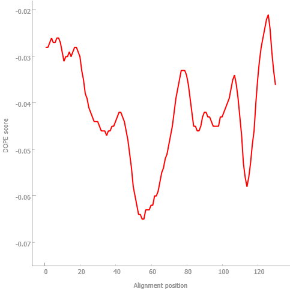

```python
myImage2
```

[figure not shown]

```python
myImage3
```

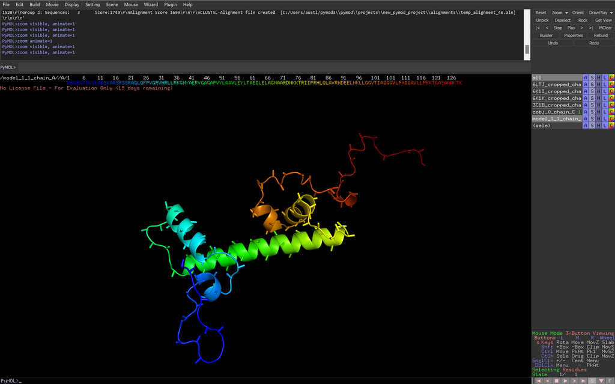

```python
#the predicted protein structre of H2AX from homology modelling using MODELLER in PyMOD 3
myImage4
```

## Part 3A: Clustering, Phylogenetic Tree, and Heatmap (Analysis Methods)

Hierarchical Clustering

```python
#reading in the datafile downloaded from the NCBI website
BLAST_clustering_data = pd.read_csv('H2AXGWS_BLASTP_forclustering.csv')

#code checks
print(BLAST_clustering_data.shape)
print(BLAST_clustering_data.dtypes)
print(BLAST_clustering_data.head())
```

```
(100, 9)
Description         object
Scientific Name     object
Acession            object
Acc. Len             int64
Max Score            int64
E value            float64
Query Cover (%)    float64
Per. ident         float64
Total Score          int64
dtype: object
                                         Description Scientific Name Acession  \
0       Chain C, Histone H2A type 1 [Xenopus laevis]  Xenopus laevis   6LTJ_C
1  Human nucleosome core particle with gammaH2A.X...    Homo sapiens   6K1I_C
2  Human nucleosome core particle with H2A.X S139...    Homo sapiens   6K1K_C
3                Chain E, Histone H2A [Homo sapiens]    Homo sapiens   7TRF_E
4  Crystal structure of human nucleosome containi...    Homo sapiens   6KVD_C

   Acc. Len  Max Score       E value  Query Cover (%)  Per. ident  Total Score
0       130        197  5.000000e-66              0.9       94.92          197
1       146        197  6.000000e-66              0.9       96.61          197
2       146        197  8.000000e-66              0.9       96.61          197
3       129        194  6.000000e-65              0.9       94.92          194
4       132        194  6.000000e-65              0.9       94.92          194
```

```python
H2AXGWS_BLASTP_forclustering = pd.read_csv("H2AXGWS_BLASTP_forclustering.csv")
#H2AXGWS_BLASTP_forclustering = H2AXGWS_BLASTP_forclustering.set_index()
print(H2AXGWS_BLASTP_forclustering.shape)

len(H2AXGWS_BLASTP_forclustering.filter(regex='_mean$',axis=1).columns)

# changing the dtypes from str to float so there are no issues with analysis
BLAST_clustering_data.iloc[:,3:]=BLAST_clustering_data.iloc[:,3:].astype(np.float64)
#code checks
print(H2AXGWS_BLASTP_forclustering.dtypes)
H2AXGWS_BLASTP_forclustering.head()
```

```
(100, 9)
Description         object
Scientific Name     object
Acession            object
Acc. Len             int64
Max Score            int64
E value            float64
Query Cover (%)    float64
Per. ident         float64
Total Score          int64
dtype: object
```

|  | Description | Scientific Name | Acession | Acc. Len | Max Score | E value | Query Cover (%) | Per. ident | Total Score |
| --- | --- | --- | --- | --- | --- | --- | --- | --- | --- |
| 0 | Chain C, Histone H2A type 1 [Xenopus laevis] | Xenopus laevis | 6LTJ_C | 130 | 197 | 5.000000e-66 | 0.9 | 94.92 | 197 |
| 1 | Human nucleosome core particle with gammaH2A.X... | Homo sapiens | 6K1I_C | 146 | 197 | 6.000000e-66 | 0.9 | 96.61 | 197 |
| 2 | Human nucleosome core particle with H2A.X S139... | Homo sapiens | 6K1K_C | 146 | 197 | 8.000000e-66 | 0.9 | 96.61 | 197 |
| 3 | Chain E, Histone H2A [Homo sapiens] | Homo sapiens | 7TRF_E | 129 | 194 | 6.000000e-65 | 0.9 | 94.92 | 194 |
| 4 | Crystal structure of human nucleosome containi... | Homo sapiens | 6KVD_C | 132 | 194 | 6.000000e-65 | 0.9 | 94.92 | 194 |

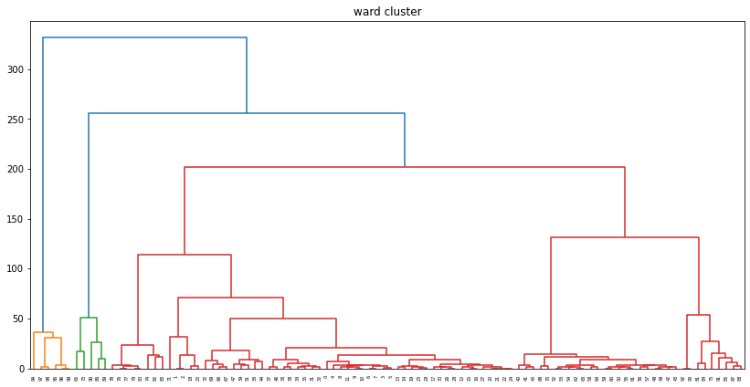

```python
#Here is the code to run the correct hierarchical clustering, where the variables mergings are defined and the linkage shows which file to use, with the dropping of the non float
# cells and the method being defined. Here is code for four clustering methods, with ward being shown and the figure size being defined and the mergings shown


#mergings_single = linkage(H2AXGWS_BLASTP_forclustering.drop(['Description', 'Scientific Name', 'Acession'], axis=1), method="single")
#plt.figure(figsize=(14, 7))
#dendrogram(mergings_single)
#plt.title("single cluster")
#plt.show()

#mergings_complete = linkage(H2AXGWS_BLASTP_forclustering.drop(['Description', 'Scientific Name', 'Acession'], axis=1), method="complete")
#plt.figure(figsize=(14, 7))
#dendrogram(mergings_complete)
#plt.title("complete")
#plt.show()

#mergings_average = linkage(H2AXGWS_BLASTP_forclustering.drop(['Description', 'Scientific Name', 'Acession'], axis=1), method="average")
#plt.figure(figsize=(14, 7))
#dendrogram(mergings_average)
#plt.title("average cluster")
#plt.show()

mergings_ward = linkage(H2AXGWS_BLASTP_forclustering.drop(['Description', 'Scientific Name', 'Acession'], axis=1), method="ward")
plt.figure(figsize=(14, 7))
dendrogram(mergings_ward)
plt.title("ward cluster")
plt.show()
```

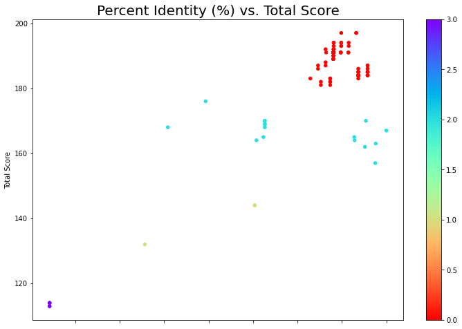

```python
#below is the code for the k-means clustering method to further show the correct analysis from hierarchical clustering
# Creating a scatterplot from the data

H2AXGWS_BLASTP_forclustering.plot.scatter('Per. ident', 'Total Score', c=cluster.labels_, cmap='rainbow_r', figsize=(12,8))
plt.title('Percent Identity (%) vs. Total Score', fontsize = 20)
```

Below shows the results from a MUSCLE search of the above H2AX protein of great white sharks, downloaded as an .aln file so that MultipleSeqAlignment can be performed. MultipleSeqAlignment takes the .aln file and the genes that are within the dataset and the TreeConstruction can be performed, with the resulting distance matrix being created that allows for results to be plotted in both the phylogenetic tree and the heatmap.

Phylogenetic tree

```python
# Open the alignment file as a MultipleSeqAlignment object
with open("muscleresultsh2ax.aln","r") as aln:
    alignment = AlignIO.read(aln,"clustal")
print(type(alignment))
```

```
<class 'Bio.Align.MultipleSeqAlignment'>
```

```python
# Open and initiate the Distance Calculator using the Identity model
calculator = DistanceCalculator('identity')
```

```python
# Writing the Distance Matrix, where distance_matrix is a global variable
distance_matrix = calculator.get_distance(alignment)
print(distance_matrix)
```

```
1F66_C:26-119	0
3WA9_C:29-122	0.0	0
4CAY_A:9-102	0.0	0.0	0
5FUG_A:8-101	0.0	0.0	0.0	0
3WAA_C:29-122	0.008403361344537785	0.008403361344537785	0.008403361344537785	0.008403361344537785	0
1U35_C:23-114	0.3697478991596639	0.3697478991596639	0.3697478991596639	0.3697478991596639	0.3697478991596639	0
7KBD_C:1-118	0.5378151260504201	0.5378151260504201	0.5378151260504201	0.5378151260504201	0.5378151260504201	0.4873949579831933	0
6M2M_A:12-92	0.3529411764705882	0.3529411764705882	0.3529411764705882	0.3529411764705882	0.3529411764705882	0.32773109243697474	0.4789915966386554	0
7BP2_A:12-92	0.3529411764705882	0.3529411764705882	0.3529411764705882	0.3529411764705882	0.3529411764705882	0.32773109243697474	0.4789915966386554	0.0	0
7DLX_A:120-208	0.32773109243697474	0.32773109243697474	0.32773109243697474	0.32773109243697474	0.32773109243697474	0.31092436974789917	0.39495798319327735	0.24369747899159666	0.24369747899159666	0
6UPH_C:16-133	0.5378151260504201	0.5378151260504201	0.5378151260504201	0.5378151260504201	0.5378151260504201	0.45378151260504207	0.26050420168067223	0.46218487394957986	0.46218487394957986	0.2941176470588235	0
4KUD_C:25-119	0.33613445378151263	0.33613445378151263	0.33613445378151263	0.33613445378151263	0.33613445378151263	0.26890756302521013	0.38655462184873945	0.26890756302521013	0.26890756302521013	0.09243697478991597	0.2016806722689075	0
4WNN_A:25-119	0.33613445378151263	0.33613445378151263	0.33613445378151263	0.33613445378151263	0.33613445378151263	0.26890756302521013	0.38655462184873945	0.26890756302521013	0.26890756302521013	0.09243697478991597	0.2016806722689075	0.0	0
7ON1_c:27-121	0.33613445378151263	0.33613445378151263	0.33613445378151263	0.33613445378151263	0.33613445378151263	0.26890756302521013	0.38655462184873945	0.26890756302521013	0.26890756302521013	0.09243697478991597	0.2016806722689075	0.0	0.0	0
4JJN_C:24-118	0.33613445378151263	0.33613445378151263	0.33613445378151263	0.33613445378151263	0.33613445378151263	0.26890756302521013	0.38655462184873945	0.26890756302521013	0.26890756302521013	0.09243697478991597	0.2016806722689075	0.0	0.0	0.0	0
1ID3_C:24-118	0.33613445378151263	0.33613445378151263	0.33613445378151263	0.33613445378151263	0.33613445378151263	0.26890756302521013	0.38655462184873945	0.26890756302521013	0.26890756302521013	0.09243697478991597	0.2016806722689075	0.0	0.0	0.0	0.0	0
6QLD_g:9-103	0.33613445378151263	0.33613445378151263	0.33613445378151263	0.33613445378151263	0.33613445378151263	0.26890756302521013	0.38655462184873945	0.26890756302521013	0.26890756302521013	0.09243697478991597	0.2016806722689075	0.0	0.0	0.0	0.0	0.0	0
5BT1_C:36-130	0.33613445378151263	0.33613445378151263	0.33613445378151263	0.33613445378151263	0.33613445378151263	0.26890756302521013	0.38655462184873945	0.26890756302521013	0.26890756302521013	0.09243697478991597	0.2016806722689075	0.0	0.0	0.0	0.0	0.0	0.0	0
6QLD_i:9-102	0.32773109243697474	0.32773109243697474	0.32773109243697474	0.32773109243697474	0.32773109243697474	0.26050420168067223	0.39495798319327735	0.26050420168067223	0.26050420168067223	0.08403361344537819	0.2100840336134454	0.008403361344537785	0.008403361344537785	0.008403361344537785	0.008…
6K00_D:111-205	0.31092436974789917	0.31092436974789917	0.31092436974789917	0.31092436974789917	0.31092436974789917	0.25210084033613445	0.3613445378151261	0.2184873949579832	0.2184873949579832	0.18487394957983194	0.31932773109243695	0.134453781512605	0.134453781512605	0.134453781512605	0.134453781512…
6DZT_C:23-117	0.3025210084033614	0.3025210084033614	0.3025210084033614	0.3025210084033614	0.3025210084033614	0.26890756302521013	0.3613445378151261	0.2184873949579832	0.2184873949579832	0.17647058823529416	0.31092436974789917	0.12605042016806722	0.12605042016806722	0.12605042016806722	0.126050420168…
2NQB_C:22-116	0.3025210084033614	0.3025210084033614	0.3025210084033614	0.3025210084033614	0.3025210084033614	0.26890756302521013	0.3613445378151261	0.2184873949579832	0.2184873949579832	0.17647058823529416	0.31092436974789917	0.12605042016806722	0.12605042016806722	0.12605042016806722	0.126050420168…
5WCU_C:9-103	0.3025210084033614	0.3025210084033614	0.3025210084033614	0.3025210084033614	0.3025210084033614	0.26890756302521013	0.3613445378151261	0.2184873949579832	0.2184873949579832	0.17647058823529416	0.31092436974789917	0.12605042016806722	0.12605042016806722	0.12605042016806722	0.1260504201680…
2PYO_C:22-116	0.3025210084033614	0.3025210084033614	0.3025210084033614	0.3025210084033614	0.3025210084033614	0.26890756302521013	0.3613445378151261	0.2184873949579832	0.2184873949579832	0.17647058823529416	0.31092436974789917	0.12605042016806722	0.12605042016806722	0.12605042016806722	0.126050420168…
4X23_C:8-102	0.3025210084033614	0.3025210084033614	0.3025210084033614	0.3025210084033614	0.3025210084033614	0.26890756302521013	0.3613445378151261	0.2184873949579832	0.2184873949579832	0.17647058823529416	0.31092436974789917	0.12605042016806722	0.12605042016806722	0.12605042016806722	0.1260504201680…
3X1T_C:23-117	0.2941176470588235	0.2941176470588235	0.2941176470588235	0.2941176470588235	0.2941176470588235	0.25210084033613445	0.3697478991596639	0.23529411764705888	0.23529411764705888	0.134453781512605	0.2941176470588235	0.10084033613445376	0.10084033613445376	0.10084033613445376	0.1008403361344…
```

[output cut: 75 more lines]

```python
#here is the code to download the distance matrix as a .txt file to be manipulated as a .csv for further analysis using excel
file1 = open("distance_matrix.txt", "w")
file1.write("%s = %s\n" %("distance_matrix", distance_matrix))
file1.close()
```

```python
# Opening and initiating the Tree Constructor
constructor = DistanceTreeConstructor(calculator)
```

```python
# Building the tree, with H2AX_tree being a global variable
H2AX_tree = constructor.build_tree(alignment)
H2AX_tree.rooted = True
print(H2AX_tree)
```

```
Tree(rooted=True)
    Clade(branch_length=0, name='Inner98')
        Clade(branch_length=0.0, name='Inner97')
            Clade(branch_length=0.0, name='Inner96')
                Clade(branch_length=0.0, name='Inner95')
                    Clade(branch_length=1.747067235093741e-05, name='Inner93')
                        Clade(branch_length=0.00011383184865745594, name='Inner92')
                            Clade(branch_length=0.008277050444201104, name='7E8I_C:1-117')
                            Clade(branch_length=0.00012836250222747828, name='Inner91')
                                Clade(branch_length=0.00490703101919478, name='Inner90')
                                    Clade(branch_length=0.00332281146508083, name='Inner89')
                                        Clade(branch_length=0.00032664066603205026, name='Inner88')
                                            Clade(branch_length=3.730185255557822e-07, name='Inner87')
                                                Clade(branch_length=0.0, name='6WKR_K:1-118')
                                                Clade(branch_length=0.0, name='Inner86')
                                                    Clade(branch_length=0.0, name='6FTX_C:1-118')
                                                    Clade(branch_length=0.0, name='4KGC_C:1-118')
                                            Clade(branch_length=0.00840298832601223, name='6G0L_C:1-118')
                                        Clade(branch_length=0.00807672067850579, name='6LTJ_C:1-118')
                                    Clade(branch_length=0.020301640757214315, name='Inner85')
                                        Clade(branch_length=0.004023262289534958, name='Inner83')
                                            Clade(branch_length=0.003272930113207388, name='Inner82')
                                                Clade(branch_length=0.003685478402786886, name='7A08_b:1-117')
                                                Clade(branch_length=0.00314225268965006, name='Inner71')
                                                    Clade(branch_length=0.0023720387508030863, name='6C0W_C:1-118')
                                                    Clade(branch_length=0.0018296419214658566, name='Inner70')
                                                        Clade(branch_length=0.0019389362274408808, name='Inner68')
                                                            Clade(branch_length=0.0019107776206500754, name='Inner67')
                                                                Clade(branch_length=0.0022747135963760608, name='2HIO_A:1-117')
                                                                Clade(branch_length=0.00612864774816178, name='Inner63')
                                                                    Clade(branch_length=0.004318394024276362, name='Inner60')
                                                                        Clade(branch_length=0.0, name='7JZV_N:5-121')
                                                                        Clade(branch_length=0.0, name='6SE0_C:1-117')
                                                                    Clade(branch_length=0.004084967320261423, name='6SE0_G:1-118')
                                                            Clade(branch_length=0.002290903051618852, name='Inner66')
                                                                Clade(branch_length=0.006623332482851085, name='Inner62')
                                                                    Clade(branch_length=0.0, name='6KVD_C:4-121')
                                                                    Clade(branch_length=0.0, name='7TRF_E:1-118')
                                                                Clade(branch_length=0.0017800288616867006, name='Inner65')
                                                                    Clade(branch_length=6.664689083359446e-05, name='1EQZ_A:1-118')
```

[output cut: 144 more lines]

```
                                                        Clade(branch_length=2.03206282513059e-05, name='Inner77')
                                                            Clade(branch_length=0.00840336134453784, name='Inner61')
                                                                Clade(branch_length=-2.42861286636753e-17, name='6JR0_C:5-121')
                                                                Clade(branch_length=0.00840336134453781, name='6JR1_C:5-121')
                                                            Clade(branch_length=0.0, name='3X1S_C:1-117')
                                                        Clade(branch_length=0.025189763405362133, name='5Z23_C:5-121')
                                Clade(branch_length=0.016583627011595683, name='1ZLA_C:1-117')
                        Clade(branch_length=0.008385890672186848, name='5OMX_C:1-117')
                    Clade(branch_length=0.0, name='Inner94')
                        Clade(branch_length=0.0, name='1ZBB_C:1-117')
                        Clade(branch_length=0.0, name='6W5I_I:4-120')
                Clade(branch_length=0.0, name='3C1B_C:1-117')
            Clade(branch_length=0.0, name='1M18_C:1-117')
        Clade(branch_length=0.0, name='1S32_C:1-117')
        Clade(branch_length=0.0, name='1KX3_C:1-117')
```

```python
# Saving the tree to a new .xml file
Phylo.write(H2AX_tree, "H2AX_tree.xml", "phyloxml")
```

```
1
```

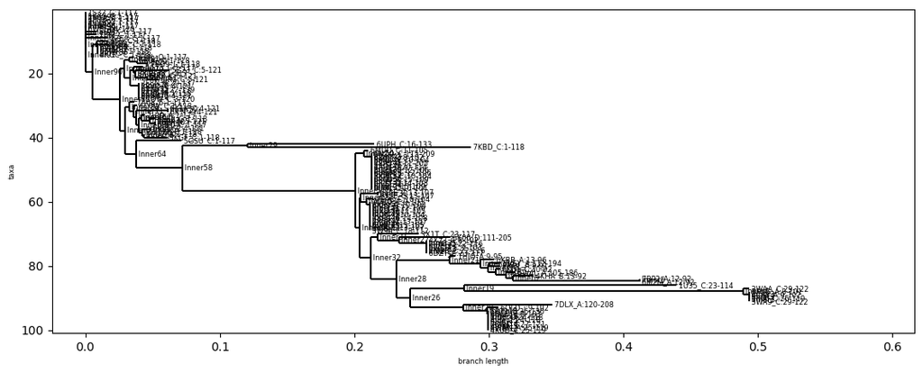

```python
# Making a phylogenetic tree using features from matplotlib
# https://www.youtube.com/watch?v=wBdz3vFQ4Ks

fig = plt.figure(figsize=(13, 5), dpi=100) # creating figure & set the size
matplotlib.rc('font', size=6)
matplotlib.rc('xtick', labelsize=10)       # fontsize of the x labels
matplotlib.rc('ytick', labelsize=10)       # fontsize of the y labels
H2AX_tree.ladderize()
axes = fig.add_subplot(1, 1, 1)
Phylo.draw(H2AX_tree, axes=axes)
fig.savefig("H2AX_cladogram")
```

```python
# Converting the tree to a different format (optional)
Phylo.convert("H2AX_tree.xml", "phyloxml", "H2AX_tree.nex", "nexus")
```

```
1
```

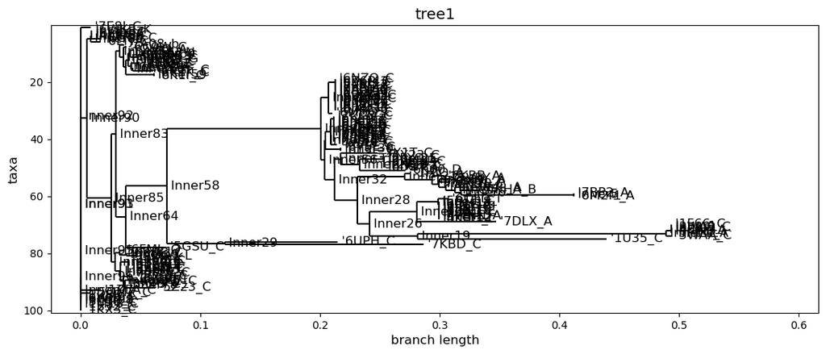

```python
#optional code to edit the phylogenetic tree below
H2AX_nex = Phylo.read("H2AX_tree.nex", "nexus")

fig = plt.figure(figsize=(13, 5), dpi=100) # creating figure & set the size
matplotlib.rc('font', size=12)
matplotlib.rc('xtick', labelsize=10)       # fontsize of the x labels
matplotlib.rc('ytick', labelsize=10)       # fontsize of the y labels
#turtle_tree.ladderize()
axes = fig.add_subplot(1, 1, 1)
Phylo.draw(H2AX_nex, axes=axes)
fig.savefig("H2AX2_cladogram")
```

Heatmap

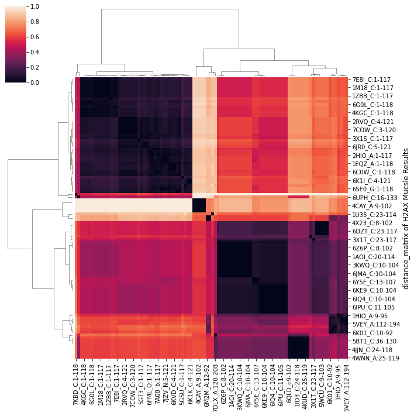

```python
#here the heatmap data is taken from the distance_matrix which was downloaded as a .txt file and converted to a .csv file for heatmap analysis
#url and df are global variables, and here is the code shown for four different methods of hierarchical clustering below, where the clustermap focuses on the df with the set.index of the gene names
# Data set
url = 'distmatrix.csv'
df = pd.read_csv(url)
df2 = df.set_index('distance_matrix of H2AX Mucsle Results')

# linkage method to use for calculating clusters: single
#sns.clustermap(df2, metric="euclidean", standard_scale=1, method="single")
#plt.show()

# linkage method to use for calculating clusters: complete
#sns.clustermap(df2, metric="euclidean", standard_scale=1, method="complete")
#plt.show()

# linkage method to use for calculating clusters: average
#sns.clustermap(df2, metric="euclidean", standard_scale=1, method="average")
#plt.show()

# linkage method to use for calculating clusters: ward
sns.clustermap(df2, metric="euclidean", standard_scale=1, method="ward")
plt.show()
```